# Homework 3-DATA 624

Kenan Sooklall

6/13/2021

ARIMA - AutoRegressive Integrated Moving Average p= order of the autoregressive part d= degree of first differencing involved q= order of the moving average part

#### Exercise 8.1

- 1. Explain the differences among these figures. Do they all indicate that the data are white noise?

- 2. Why are the critical values at different distances from the mean of zero? Why are the autocorrelations different in each figure when they each refer to white noise?

From the equation for critical values $\pm 1.96/sqrt(T)$ we see that as T (length of the time series) get’s larger the critical value becomes smaller. So with a smaller sample size, the ACF can capture the autocorrelation clearer.

#### Exercise 8.2

A classic example of a non-stationary series is the daily closing IBM stock price series (data set ibmclose). Use R to plot the daily closing prices for IBM stock and the ACF and PACF. Explain how each plot shows that the series is non-stationary and should be differenced.

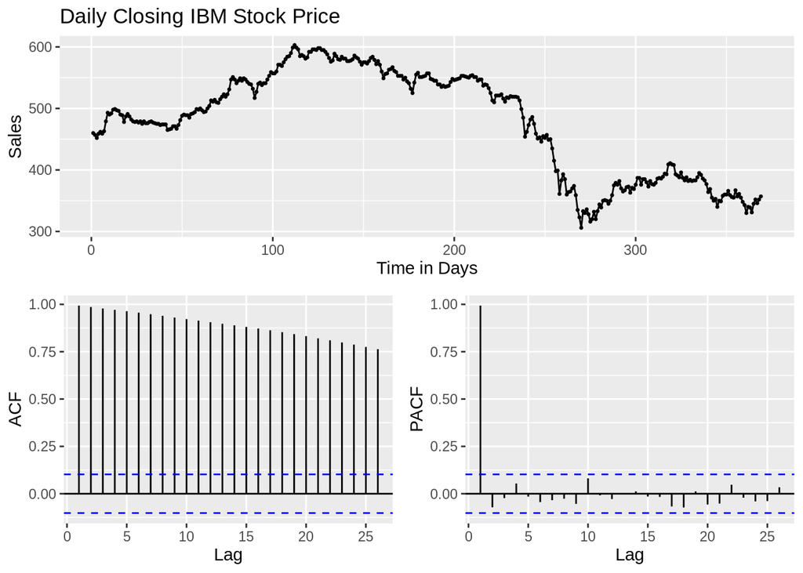

```r
ggtsdisplay(ibmclose, main = "Daily Closing IBM Stock Price", ylab = "Sales", xlab = "Time in Days")
```

The timeseries plot shows no clear trend like what we would expected from seasonal data thus making the series non-stationary. The ACF plot shows a a constant but slow decrease. The PACF plot spikes at the first T and then all other values are within the critical values. All together we can conclude that IBM stock price is non-stationary.

#### Exercise 8.6

Use R to simulate and plot some data from simple ARIMA models.

- 1. Use the following R code to generate data from an AR(1) model with  
     $\phi_1=0.6$ and $\sigma^2=1$. The process starts with $y_1=0$

```r
ar1 <- function(phi) {
  y <- ts(numeric(100))
  e <- rnorm(100)
  for(i in 2:100) {
    y[i] <- phi*y[i-1] + e[i]
  }
  return (y)
}
```

- 2. Produce a time plot for the series. How does the plot change as you change $\phi_1$?

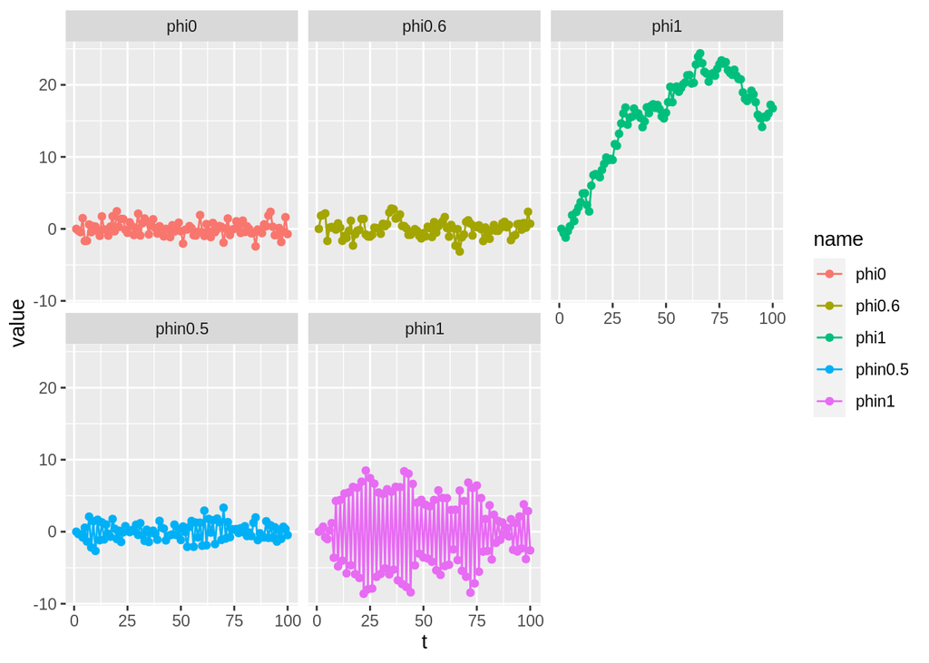

```r
df <- data.frame(phin1=ar1(-1), phin0.5=ar1(-0.5), phi0=ar1(0), phi0.6=ar1(0.6), phi1=ar1(1)) %>% mutate(t=row_number())

df %>% pivot_longer(cols = -c('t')) %>% ggplot(aes(x=t, y=value, color=name)) + geom_line() + geom_point() + facet_wrap(~name, scales='fixed')
```

As phi gets further away from 0 points on the plot spread out more in the y axis.

- 3. Write your own code to generate data from an MA(1) model with $\theta_1=0.6$ and $\sigma^2=1$.

```r
ma1 <- function(phi) {
  y <- ts(numeric(100))
  e <- rnorm(100)
  for(i in 2:100) {
    y[i] <- phi*e[i-1] + e[i]
  }
  return (y)
}
```

- 4. Produce a time plot for the series. How does the plot change as you change $\theta_1$?

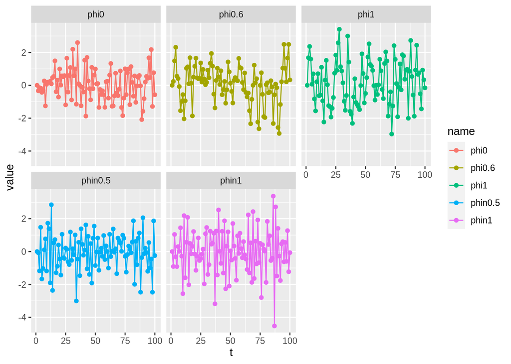

```r
df <- data.frame(phin1=ma1(-1), phin0.5=ma1(-0.5), phi0=ma1(0), phi0.6=ma1(0.6), phi1=ma1(1)) %>% mutate(t=row_number())

df %>% pivot_longer(cols = -c('t')) %>% ggplot(aes(x=t, y=value, color=name)) + geom_line() + geom_point() + facet_wrap(~name, scales = 'fixed')
```

- 5. Generate data from an ARMA(1,1) model with $\phi_1=0.6$, $\theta_1=0.6$ and $\sigma^2=1$.

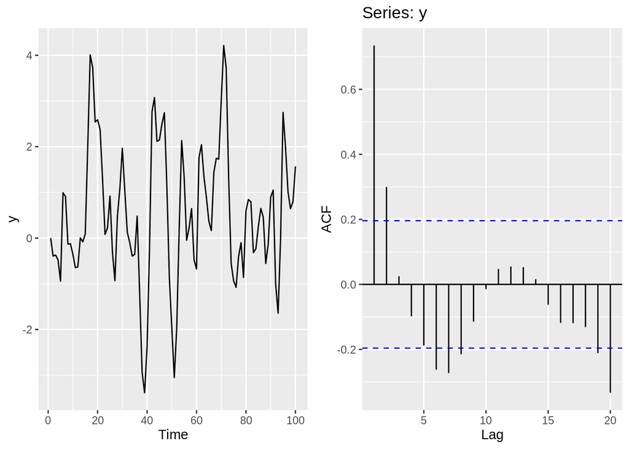

```r
ma_ar11 <- function(phi, theta) {
  y <- ts(numeric(100))
  e <- rnorm(100)
  for(i in 2:100) {
    y[i] = phi*y[i-1] + theta*e[i-1] + e[i]
  }
  return (y)
}

y = ma_ar11(0.6, 0.6)
p1 = autoplot(y)
p2 = ggAcf(y)
gridExtra::grid.arrange(p1, p2, ncol = 2)
```

- 6. Generate data from an AR(2) model with $\phi_1=-0.8$, $\phi_2=0.3$ and $\sigma^2=1$. (Note that these parameters will give a non-stationary series.)

```r
ar2 <- function(phi_1, phi_2) {
  y <- ts(numeric(100))
  e <- rnorm(100, 1)
  for(i in 3:100) {
    y[i] <- phi_1*y[i-1] + phi_2*y[i-2] + e[i]
  }
  return (y)
}
yar2 = ar2(-0.8, 0.3)
```

- 7. Graph the latter two series and compare them.

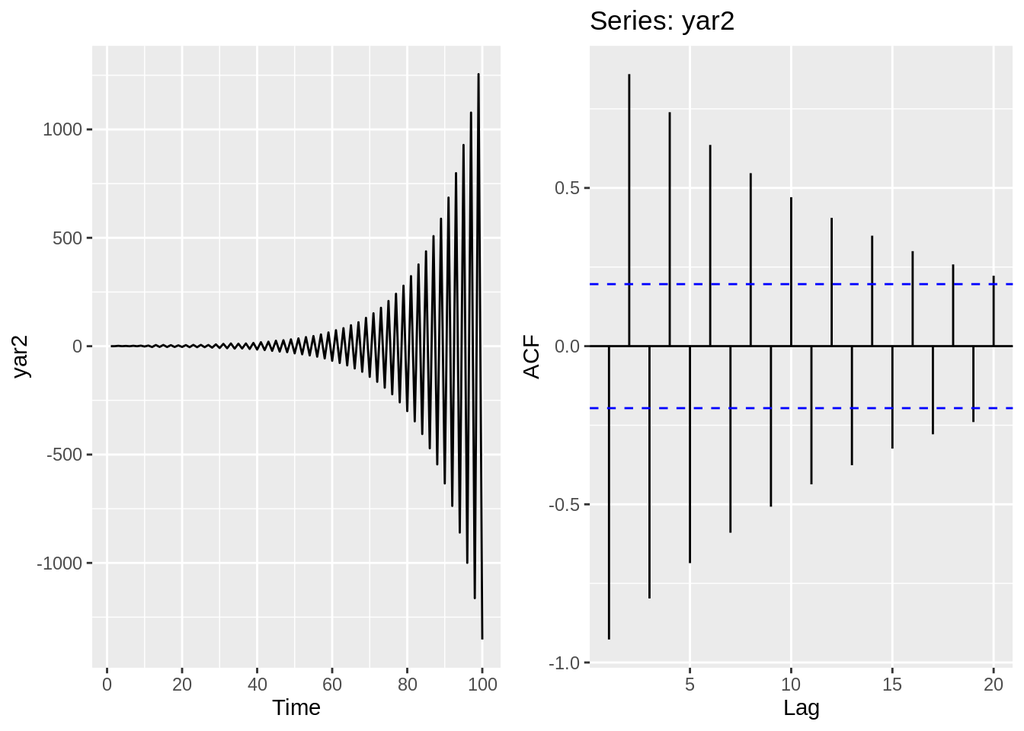

```r
p1 = autoplot(yar2)
p2 = ggAcf(yar2)
gridExtra::grid.arrange(p1, p2, ncol = 2)
```

#### Exercise 8.8

Consider austa, the total international visitors to Australia (in millions) for the period 1980-2015.

- 1. Use auto.arima() to find an appropriate ARIMA model. What model was selected. Check that the residuals look like white noise. Plot forecasts for the next 10 periods.

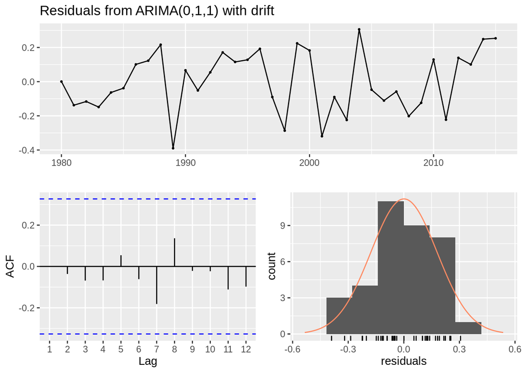

```
##
##  Ljung-Box test
##
## data:  Residuals from ARIMA(0,1,1) with drift
## Q* = 2.297, df = 5, p-value = 0.8067
##
## Model df: 2.   Total lags used: 7
```

```r
fit011 <- auto.arima(austa)
checkresiduals(fit011)
```

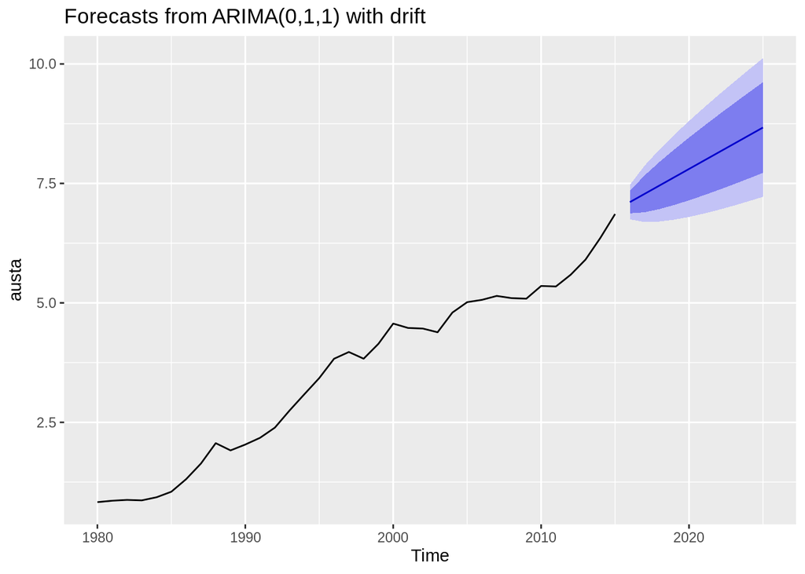

```r
autoplot(forecast(fit011, h=10))
```

All values in the ACF plot are within the threshold.

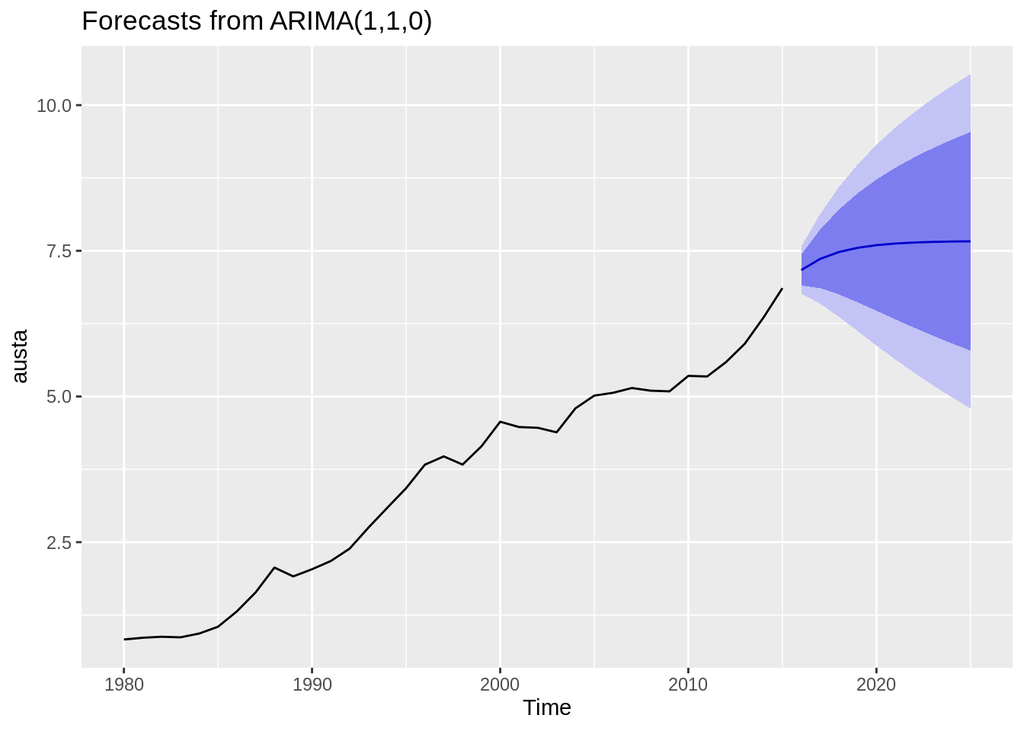

```r
fit011 <- auto.arima(austa, allowdrift=F)
autoplot(forecast(fit011, h=10))
```

- 3. Plot forecasts from an ARIMA(2,1,3) model with drift.

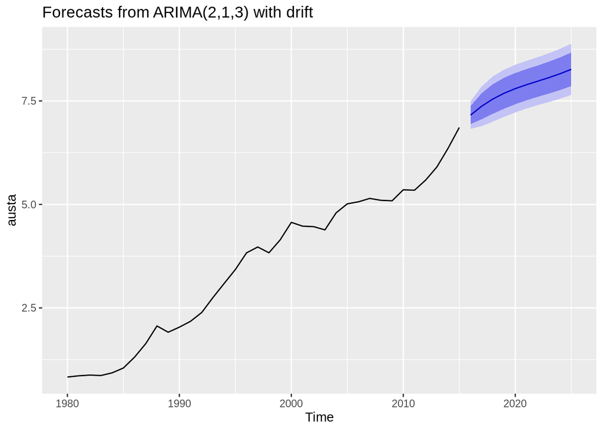

```r
fit <- Arima(austa, order=c(2,1,3), method='ML', include.drift=T)
autoplot(forecast(fit,h=10))
```

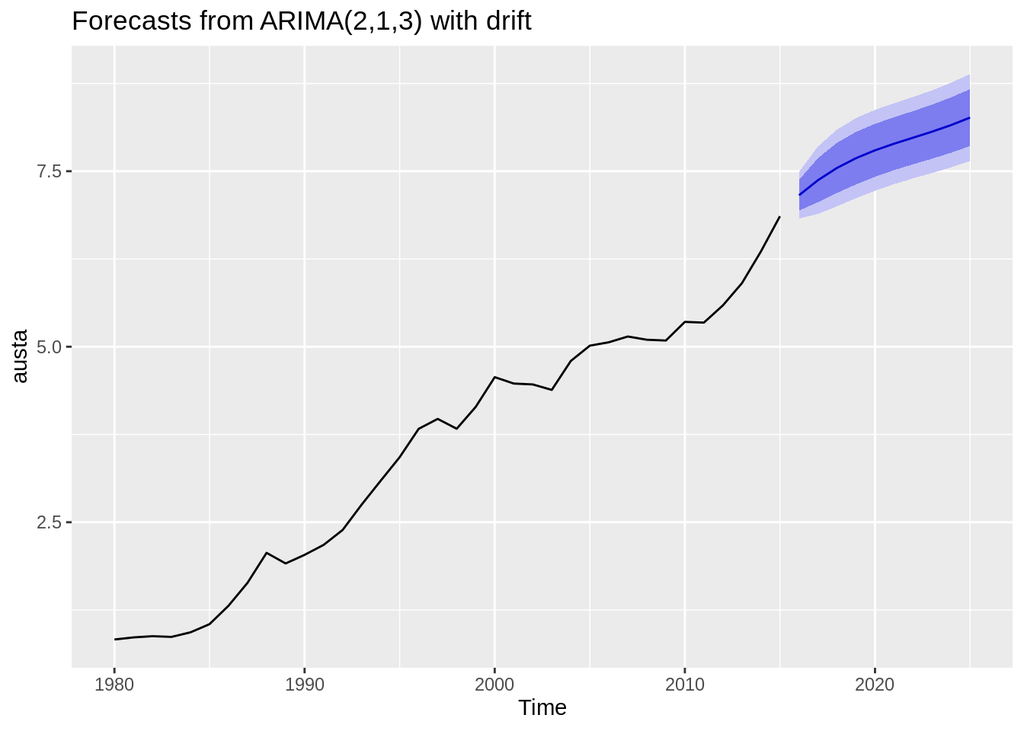

```r
fit <- Arima(austa, order=c(2,1,3), method='ML', include.drift=T, include.mean =F)
autoplot(forecast(fit,h=10))
```

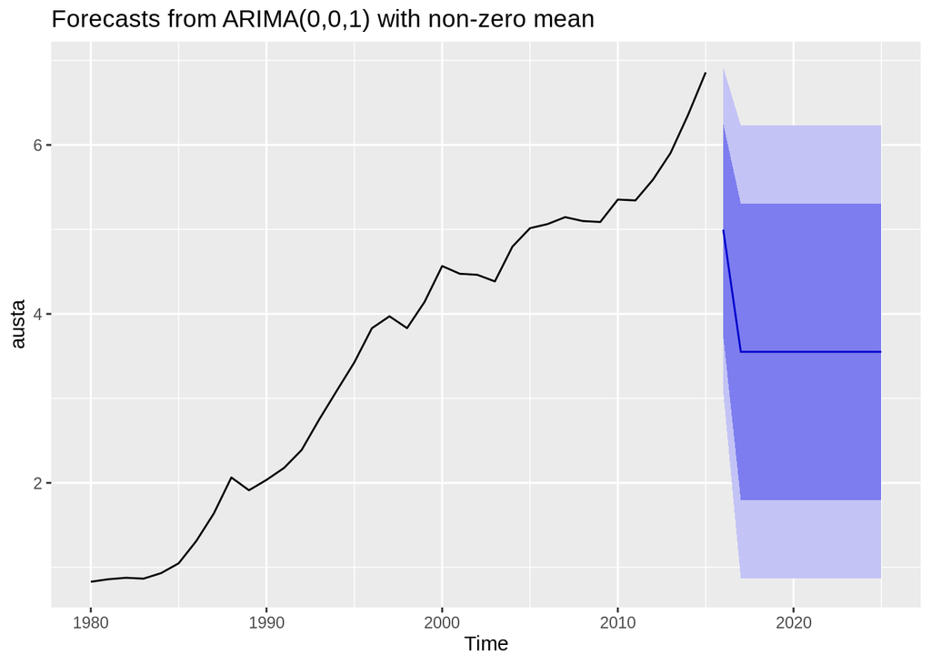

```r
fit <- Arima(austa, order=c(0,0,1), method='ML')
autoplot(forecast(fit,h=10))
```

- 5. Plot forecasts from an ARIMA(0,2,1) model with no constant.

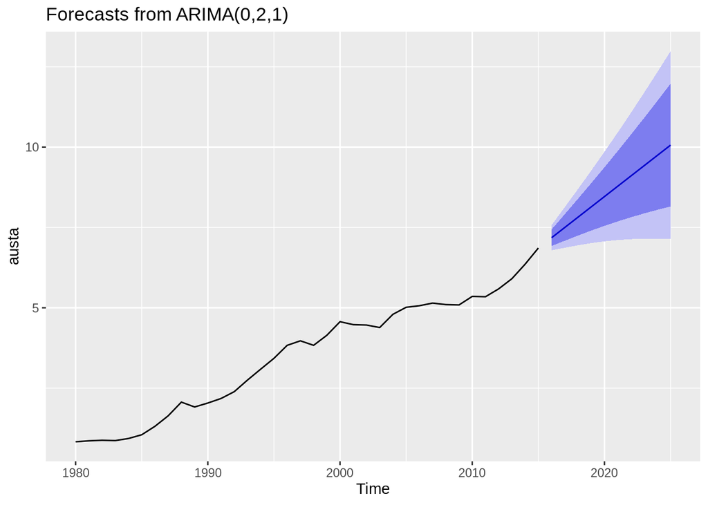

```r
fit <- Arima(austa, order=c(0,2,1), method='ML', include.mean=F)
autoplot(forecast(fit,h=10))
```